# Import Data with R

GT

6 novembre 2016

## Part 1

### Importing data from flat file…

Lots of data comes in the form of flat files: simple tabular text files. Learn how to import all common formats of flat file data with base R functions.

#### read.csv

The `utils` package, which is automatically loaded in you R session on startup, can import CSV files with the `read.csv()` function.

```r
# Import swimming_pools.csv
pools <- read.csv("swimming_pools.csv")

# Print the structure of pools
str(pools)
```

#### stringAsFactors

With `stringAsFactors`, you can tell R whether it should convert strings in the flat file to factors.

For all importing functions in the `utils` package, this argument is `TRUE`, which means that you import strings as factors. This only makes sense if the strings you import represent categorical variables in R. If you set `stringAsFactors` to `FALSE`, the data frame columns corresponding to strings in your text file will be `character`.

```r
# Import swimming_pools.csv correctly: pools
pools <- read.csv("swimming_pools.csv", stringsAsFactors = FALSE)

# Check the structure of pools
str(pools)
```

#### read.delim

Aside from `.csv` files, there are also the `.txt` files which are basically text files. You can import these functions with `read.delim()`. By default, it sets the `sep` argument to `"\t"` (fields in a record are delimited by tabs) and the `header` argument to `TRUE` (the first row contains the field names).

```r
# Import hotdogs.txt: hotdogs
hotdogs <- read.delim("hotdogs.txt", header = FALSE)

# Summarize hotdogs
summary(hotdogs)
```

#### read.table

If you’re dealing with more exotic flat file formats, you’ll want to use `read.table()`. It’s the most basic importing function; you can specify tons of different arguments in this function. Unlike `read.csv()` and `read.delim()`, the `header` argument defaults to `FALSE` and the `sep` argument is `""` by default.

```r
# Path to the hotdogs.txt file: path
path <- file.path("data", "hotdogs.txt")

# Import the hotdogs.txt file: hotdogs
hotdogs <- read.table(path,
                      sep = "\t",
                      col.names = c("type", "calories", "sodium"))

# Call head() on hotdogs
head(hotdogs)
```

#### Arguments

You can specify the column names of the data frame.

```r
hotdogs <- read.delim("hotdogs.txt",
                      header = FALSE,
                      col.names = c("type",
                                    "calories",
                                    "sodium"))

# Selct the hot dog with the leas calories: lily
lily <- hotdogs[which.min(hotdogs$calories),]
```

#### Column classes

Next to column names, you can also specify the column types or column classes of the resulting data frame. You can do this by setting the `colClasses` argument to a vector of strings representing classes:

```
read.delim("my_file.txt",
            colClasses = c("character",
                            "numeric",
                            "logical"))
```

This approach can be useful if you have some columns that should be factors and others that should be characters. You don’t have to bother with `stringAsFactors` anymore; just state for each column what the class should be.

If a column is set to `"NULL"` in the `colClasses` vector, this column will be skipped and will not be loaded into the data frame.

```r
# Import the data correctly: hotdogs2
hotdogs2 <- read.delim("hotdogs.txt", header = FALSE,
                       col.names = c("type", "calories", "sodium"),
                       colClasses = c("factor", "NULL", "numeric"))

# Display structure of hotdogs2
str(hotdogs2)
```

### readr & data.table

Next to base R, there are also dedicated packages to easily and efficiently import flat file data. We’ll talk about two such packages: readr and data.table.

#### read_csv

CSV files can be imported with `read_csv()`. It’s a wrapper function around `read_delim()` that handles all the details for you. For example, it will assume that the first row contains the column names.

```r
# Load the readr package
library(readr)

# Import potatoes.csv with read_csv(): potatoes
potatoes <- read_csv("potatoes.csv")
```

#### read_tsv

Where you use `read_csv()` to easily read in CSV files, you use `read_tsv()` to easily read in TSV files. TSV is short for tab-separated values.

```r
# readr is already loaded

# Column names
properties <- c("area", "temp", "size", "storage", "method",
                "texture", "flavor", "moistness")

# Import potatoes.txt: potatoes
potatoes <- read_tsv("potatoes.txt", col_names = properties)

# Call head() on potatoes
head(potatoes)
```

#### read_delim

Just as `read.table()` was the main `utils` function, `read_delim()` is the main `readr` function.

`read_delim()` takes two mandatory arguments:

- `file`: the file that contains the data
- `delim`: the character that separates the values in the data file

```r
# readr is already loaded

# Column names
properties <- c("area", "temp", "size", "storage", "method",
                "texture", "flavor", "moistness")

# Import potatoes.txt using read_delim(): potatoes
potatoes <- read_delim("potatoes.txt", delim = "\t", col_names = properties)
```

#### skip and n_max

Through `skip` and `n_max` you can control which part of your flat file you’re actually importing into R.

- `skip` specifies the number of lines you’re ignoring in the flat file before actually starting to import data.
- `n_max` specifies the number of lines you’re actually import.

Say for example you have a CSV file with 20 lines, and set `skip = 2` and `n_max = 3`, you’re only reading in lines 3, 4 and 5 of the file.

Watch Out: Once you `skip` some lines, you also skip the first line that can contain column names!

```r
# readr is already loaded

# Column names
properties <- c("area", "temp", "size", "storage", "method",
                "texture", "flavor", "moistness")

# Import 5 observations from potatoes.txt: potatoes_fragment
# Import observations 7, 8, 9, 10 and 11
potatoes_fragment <- read_tsv("potatoes.txt", skip = 6, n_max = 5,
                              col_names = properties)
```

#### col_types

You can also specify which types the columns in your imported data frame should have. You can do this with `col_types`. If set to `NULL`, the default, functions from the `readr` package will try to find the correct types themeselves. You can manually set the types with a string, where each character denotes the class of the column:

- `c`haracter
- `d`ouble
- `i`nteger
- `l`ogical
- `_` skips the column as a whole.

```r
# readr is already loaded

# Column names
properties <- c("area", "temp", "size", "storage", "method",
                "texture", "flavor", "moistness")

# Import all data, but force all columns to be character: potatoes_char
potatoes_char <- read_tsv("potatoes.txt", col_types = "cccccccc", col_names = properties)

# Print out structure of potatoes_char
str(potatoes_char)
```

#### col_types with collectors

Another way of setting the types of the imported columns is using **collectors**. Collector functions can be passed in a `list()` to the `col_types` argument of `read_` functions to tell them how to interpret values in a column.

For a complete list of collector functions, you can take a look at the `collector` documentation. For this exercise you will need two collector functions:

- `col_integer()`: the column should be interpreted as an integer.
- `col_factor(levels, ordered = FALSE`): the column should be interpreted as a factor with `levels`.

```r
# readr is already loaded

# The collectors you will need to import the data
fac <- col_factor(levels = c("Beef", "Meat", "Poultry"))
int <- col_integer()

# Edit the col_types argument to import the data correctly: hotdogs_factor
hotdogs_factor <- read_tsv("hotdogs.txt",
                           col_names = c("type", "calories", "sodium"),
                           col_types = list(fac, int, int))

# Display the summary of hotdogs_factor
summary(hotdogs_factor)
```

#### fread

You still remember how to use `read.table()`, right? Well, `fread()` is a function that does the same job withg very similar argument. It is extremely easy to use and blazingly fast! Often, simply specifying the path to the file is enough to successfully import your data.

```r
# load the data.table package
library(data.table)

# Import potatoes.csv with fread(): potatoes
potatoes <- fread("potatoes.csv")

# Print out potatoes
potatoes
```

#### fread: more advanced use

Now that you know the basic about `fread()`, you should know about two arguments of the function `drop` and `select` to drop or select variables of interest.

Suppose you have a dataset that contains 5 variables and you want to keep the first and fifth varible, named “a” and “e”. The following options will all do the trick:

```
fread("path/to/file.txt", drop = 2:4)
fread("path/to/file.txt", select = c(1,5))
fread("path/to/file.txt", drop = c("b", "c", "d"))
fread("path/to/file.txt", select = c("a", "e"))
```

```r
# fread is already loaded

# Import columns 6 and 8 of potatoes.csv: potatoes
potatoes <- fread("potatoes.csv", select = c(6, 8))

# Plot texture (x) and moistness (y) of potatoes
plot(potatoes$texture, potatoes$moistness)
```

#### Dedicated classes

You might have noticed that the `fread()` function produces data frames that look slightly different when you print them out. That’s because another class named `data.table` is assigned to the resulting data frames. The printout of such `data.table` objects is different.

The class of the result of `fread()` is both `data.table` and `data.frame`. `read_tsv()` creates an object with three classes: `tbl_df`, `tbl` and `data.frame`.

What’s the benefit of these additional classes? Well, it allows for a different treatment of printouts, for example.

### Importing Excel data

#### List the sheets of an Excel file

Before you can start importing from Excel, you should find out which sheets are available in the workbook. You can use the `excel_sheets()` function for this.

```r
# Load the readxl package
library(readxl)

# Print out the names of both spreadsheets
excel_sheets("urbanpop.xlsx")
```

`excel_sheets()` is a simple character vector; you haven’t imported anything yet.

#### Import an Excel sheet

Now that you know the names of the sheets in the Excel file you want to import, it is time to import those sheets into R. You can do this with the `read_excel()` function. Have a look at this recipe:

```
data <- read_excel("data.xlsx", sheet = "my_sheet")
```

This call simply imports the sheet with the name `"my_sheet"` from the `"data_xlsx"` file. You can also pass a number to the `sheet` argument; this will cause `read_excel()` to import the sheet with the given sheet number. `sheet = 1` will import the first sheet, `sheet = 1` will import the second sheet, and so on.

```r
# The readxl package is already loaded

# Read the sheets, one by one
pop_1 <- read_excel("urbanpop.xlsx", sheet = 1)
pop_2 <- read_excel("urbanpop.xlsx", sheet = 2)
pop_3 <- read_excel("urbanpop.xlsx", sheet = 3)

# Put pop_1, pop_2 and pop_3 in a list: pop_list
pop_list <- list(pop_1, pop_2, pop_3)

# Display the structure of pop_list
str(pop_list)
```

#### Reading a workbook

In the previous exercise you generated a list of three Excel sheets that you imported. However, loadin in every sheet manually and then merging them in a list can be quite tedious. Luckily, you can automate this with `lapply()`.

How a look at the example code below:

```
my_workbook <- lapply(excel_sheets("data.xlsx"),
                      read_excel,
                      path = "data.xlsx")
```

The `read_excel()` function is called multiple times on the `"data.xlsx"` file and each sheet is loaded in one afterr the other. The result is a list of data frames, each data frame representing one of the sheets in `data.xlsx`.

```r
# The readxl package is already loaded

# Read all Excel sheets with lapply(): pop_list
pop_list <- lapply(excel_sheets("urbanpop.xlsx"),
                    read_excel,
                    path = "urbanpop.xlsx")

# Display the structure of pop_list
str(pop_list)
```

#### The col_names argument

Apart from `path` and `sheet`, there are several othe arguements you can specify in `read_excel()`. One of these arguments is called `col_names`.

By default it is `TRUE`, denoting whether the first row in the Excel sheets contains the column names. If this is not the case, you can set `col_names` to `FALSE`. In this case, R will choose column names for you. You can also choose to set `col_names` to a character vector with names for each column. It works exactly the same as in the `readr` package.

```r
# The readxl package is already loaded

# Import the the first Excel sheet of urbanpop_nonames.xlsx (R gives names): pop_a
pop_a <- read_excel("urbanpop_nonames.xlsx", sheet = 1, col_names = FALSE)

# Import the the first Excel sheet of urbanpop_nonames.xlsx (specify col_names): pop_b
cols <- c("country", paste0("year_", 1960:1966))
pop_b <- read_excel("urbanpop_nonames.xlsx", sheet = 1, col_names = cols)

# Print the summary of pop_a
summary(pop_a)

# Print the summary of pop_b
summary(pop_b)
```

It’s really crucial to correctly tell R whether your Excel data contains column names. If you don’t, the head of the data frame you end up with will contain incorrect information…

#### The skip argument

Another argument that can be very useful when reading in Excel files that are less tidy, is `skip`. With `skip`, you can tell R to ignore a specified number of rows inside the Excel sheets you’re trying to pull data from. Have a look at this example:

```
read_excel("data.xlsx, skip = 15")
```

In this case, the first 15 rows in the first sheet of `"data.xlsx"` are ignored.

If the first row of this sheet contained the column names, this information will also be ignored by `readxl`. Make sure to set `col_names` to `FALSE` or manually specify column names in this case!

```r
# The readxl package is already loaded

# Import the second sheet of urbanpop.xlsx, skipping the first 21 rows: urbanpop_sel
urbanpop_sel <- read_excel("urbanpop.xlsx", sheet = 2, skip = 21, col_names = FALSE)

# Print out the first observation from urbanpop_sel
urbanpop_sel[1,]
```

#### Import a local file

In this part of the chapter you’ll learn how to import `.xls` files using the `gdata` package. Similar to `readxl` package, you can import sigle Excel sheets to start your analysis in R.

```r
# Load the gdata package
library(gdata)

# Import the second sheet of urbanpop.xls: urban_pop
urban_pop <- read.xls("urbanpop.xls", sheet = "1967-1974")

# Print the first 11 observations using head()
head(urban_pop, n = 11)
```

#### read.xls() wraps around read.table()

Remember how `read.xls()` actually works ? It basically comes down to two steps: converting the Excel file to a `.csv` file using a Perl script, and then reading that `.csv` file with the `read.csv()` function that is loaded by default in R, through the `utils` package.

This means that all the options that you can specify in `read.csv()`, can also specified in `read.xls()`.

```r
# The gdata package is alreaded loaded

# Column names for urban_pop
columns <- c("country", paste0("year_", 1967:1974))

# Finish the read.xls call
urban_pop <- read.xls("urbanpop.xls", sheet = 2,
                      skip = 50, header = FALSE, stringsAsFactors = FALSE,
                      col.names = columns)

# Print first 10 observation of urban_pop
head(urban_pop, n = 10)
```

#### Work that Excel data!

Now that you can read in Excel data, let’s try to clean and merge it. You already used the `cbind()` function. Let’s take it one step further now.

```r
# Add code to import data from all three sheets in urbanpop.xls
path <- "urbanpop.xls"
urban_sheet1 <- read.xls(path, sheet = 1, stringsAsFactors = FALSE)
urban_sheet2 <- read.xls(path, sheet = 2, stringsAsFactors = FALSE)
urban_sheet3 <- read.xls(path, sheet = 3, stringsAsFactors = FALSE)

# Extend the cbind() call to include urban_sheet3: urban
# Make sure the first column for urban_sheet2 and urban_sheet3 are
# removed to avoid duplicate columns.
urban <- cbind(urban_sheet1, urban_sheet2[-1], urban_sheet3[-1])

# Remove all rows with NAs from urban: urban_clean
urban_clean <- na.omit(urban)

# Print out a summary of urban_clean
summary(urban_clean)
```

### Reproducible Excel work with XLConnect

Next to importing data from Excel, you can take things one step further with XLConnect. Learn all about it and bridge the gap between R and Excel!

#### Connect to a workbook

When working with `XLConnect`, the first step will be to load a workbook in your R session with `loadWorkbook()`; this function will build a “bridge” between your Excel file and your R session.

```r
# Load the XLConnect package
library(XLConnect)

# Build connection to urbanpop.xlsx: my_book
my_book <- loadWorkbook("urbanpop.xlsx")

# Print out the class of my_book
class(my_book)
```

#### List and read Excel sheets

Just as `readxl` and `gdata`, you can use `XLConnect` to import data from Excel file into R.

To list the sheets in an Excel file, use `getSheets()`. To actually import data from a sheet, you can use `readWorksheet()`. Both function require an XLConnect workbook object as the first argument.

```r
# XLConnect is already available

# Build connection to urbanpop.xlsx
my_book <- loadWorkbook("urbanpop.xlsx")

# List the sheets in my_book
getSheets(my_book)

# Import the second sheet in my_book
readWorksheet(my_book, sheet = 2)
```

#### Customize readWorksheet

To get a clear overview about `urbanpop.xlsx` without having to open up the Excel file, you can execute the following code:

```
my_book <- loadWorkbook("urbanpop.xlsx")
sheets <- getSheets(my_book)
all <- lapply(sheets, readWorksheet, object = my_book)
str(all)
```

Suppose we’re only interested in urban population data of the years 1968, 1969 and 1970. The data for these years is in the columns 3, 4 and 5 of the second sheet. Only selecting these columns will leave us in the dark about the actual countries the figures belong to.

```r
# XLConnect is already available

# Build connection to urbanpop.xlsx
my_book <- loadWorkbook("urbanpop.xlsx")

# Import columns 3, 4, and 5 from second sheet in my_book: urbanpop_sel
urbanpop_sel <- readWorksheet(my_book, sheet = 2, startCol = 3, endCol = 5)

# Import first column from second sheet in my_book: countries
countries <- readWorksheet(my_book, sheet = 2, startCol = 1, endCol = 1)

# cbind() urbanpop_sel and countries together: selection
selection <- cbind(countries, urbanpop_sel)
```

#### Add worksheet

Where `readxl` and `gdata` were only able to import Excel data, `XLConnect`’s approach of providing an actual interface to an Excel file makes it able to edit your Excel files from inside R. In this step, you’ll create a new sheet.

```r
# XLConnect is already available

# Build connection to urbanpop.xlsx
my_book <- loadWorkbook("urbanpop.xlsx")

# Add a worksheet to my_book, named "data_summary"
createSheet(my_book, "data_summary")

# Use getSheets() on my_book
getSheets(my_book)
```

#### Populate worksheet

```r
# XLConnect is already available

# Build connection to urbanpop.xlsx
my_book <- loadWorkbook("urbanpop.xlsx")

# Add a worksheet to my_book, named "data_summary"
createSheet(my_book, "data_summary")

# Create data frame: summ
sheets <- getSheets(my_book)[1:3]
dims <- sapply(sheets, function(x) dim(readWorksheet(my_book, sheet = x)), USE.NAMES = FALSE)
summ <- data.frame(sheets = sheets,
                   nrows = dims[1, ],
                   ncols = dims[2, ])

# Add data in summ to "data_summary" sheet
writeWorksheet(my_book, summ, sheet = "data_summary")

# Save workbook as summary.xlsx
saveWorkbook(my_book, file = "summary.xlsx")
```

#### Renaming sheets

Come to think of it, `"data_summary"` is not an ideal name. As the summary of these excel sheets is always data-related, you simply want to name the sheet `"summary"`.

```r
# my_book is available

# Rename "data_summary" sheet to "summary"
renameSheet(my_book, "data_summary", "summary")

# Print out sheets of my_book
getSheets(my_book)

# Save workbook to "renamed.xlsx"
saveWorkbook(my_book, file = "renamed.xlsx")
```

#### Removing sheets

After presenting the new Excel sheet to your peers, it appears not everybody is a big fan. Why summarize sheets and store the info in Excel if all the information is implicitly available? To hell with it, just remove the entire fourth sheet!

```r
# Load the XLConnect package
library(XLConnect)

# Build connection to renamed.xlsx: my_book
my_book <- loadWorkbook("renamed.xlsx")

# Remove the fourth sheet
removeSheet(my_book, sheet = "summary")

# Save workbook to "clean.xlsx"
saveWorkbook(my_book, file = "clean.xlsx")
```

## Part 2

### Importing data from databases

Many companies store their information in relational databases. The R community has also developed R packages to get data from these architectures. You’ll learn how to connect to a database and how to retrieve data from it.

#### Establish a connection

The first step to import data from a SQL database is creating a connection to it. You need different packages depending on the database you want to connect to. All of these packages do this in a uniform way, as specified in the `DBI` package.

`dbConnect()` creates a connection between your R session and a SQL database. The first argument has to be a `DBIdriver` object, that specifies how connections are made and how data is mapped between R and the database. Specifically for MySQL databases, you can build such a driver with `RMySQL::MySQL()`.

If the MySQL database is a remote database hosted on a server, you’ll also have to specify the followinng argumements in `dbConnect()`: `dbname`, `host`, `port`, `user` and `password`.

```r
# Load the DBI package
library(DBI)

# Edit dbConnect() call
con <- dbConnect(RMySQL::MySQL(),
                 dbname = "tweater",
                 host = "courses.csrrinzqubik.us-east-1.rds.amazonaws.com",
                 port = 3306,
                 user = "student",
                 password = "datacamp")
```

#### Inspect the connection

Now that you’ve successfully created the database connection, let’s have a closer look at it.

```
class(con)
[1] "MySQLConnection"
attr(,"package")
[1] "RMySQL"
```

con is an `MySQLConnection` object.

#### List the database tables

After you’ve successfully connected to a remote MySQL database, the next step is to see what tables the database contains. You can do this with the `dbListTables()` function. As you might remember from the video, this function requires the connection object as an input, and outputs a character vector with the table names.

```r
# Build a vector of table names: tables
tables <- dbListTables(con)

# Display structure of tables
str(tables)
```

`dbListTables()` can be very useful to get a first idea about the contents of your database. Can you guess what kind of information this database contains?

#### Import users

As you might have guessed by now, the database contains data on a more tasty version of Twitter, namely Tweater. Users can post tweats with short recipes for delicious snacks. People can comment on these tweats. There are three tables: **users**, **tweats** and **comments** that have relations among them. Which ones, you ask?

Let’s start by importing the data on the users into your R session. You do this with the `dbReadTable()` function. Simply pass it the connection object (`con`), followed by the name of the table you want to import. The resulting object is a standard R data frame.

```r
# Import the users table from tweater: users
users <- dbReadTable(con, "users")

# Print users
users
```

#### Import all tables

Next to the `users`, we’re also interested in the `tweats` and `comments` tables. However, separate `dbReadTable()` call for each and every one of the tables in your database would mean a lot of code duplication. Remember about the `lapply()` function? You can use it again here!

```r
# Get table names
table_names <- dbListTables(con)

# Import all tables
tables <- lapply(table_names, dbReadTable, conn = con)

# Print out tables
tables
```

Now that you have an R version of all data that is contained in the database, you can dive a little deeper into the relations between the different data frames.

#### How do the tables relate ?

If you have a closer look at these tables, you’ll see that the `tweats` table, for example, contains a column `user_id`. The ids in the column refer to the users that have posted the tweat. Similarly, the `comments` contain both a `user_id` and a `tweat_id` column. It specifies which user posted a comment on which tweat.

With this new knowledge, can you tell **who** posted the **tweat** on which somebody **commented** “awesome!thanks!” (comment 1012)?

```
> tables
$comments
     id tweat_id user_id            message
1  1022       87       7              nice!
2  1000       77       7             great!
3  1011       49       5            love it
4  1012       87       1   awesome! thanks!
5  1010       88       6              yuck!
6  1026       77       4      not my thing!
7  1004       49       1  this is fabulous!
8  1030       75       6           so easy!
9  1025       88       2             oh yes
10 1007       49       3           serious?
11 1020       77       1 couldn't be better
12 1014       77       1       saved my day

$tweats
  id user_id
1 75       3
2 88       4
3 77       6
4 87       5
5 49       1
6 24       7
                                                                 post
1                                       break egg. bake egg. eat egg.
2                           wash strawberries. add ice. blend. enjoy.
3                       2 slices of bread. add cheese. grill. heaven.
4               open and crush avocado. add shrimps. perfect starter.
5 nachos. add tomato sauce, minced meat and cheese. oven for 10 mins.
6                              just eat an apple. simply and healthy.
        date
1 2015-09-05
2 2015-09-14
3 2015-09-21
4 2015-09-22
5 2015-09-22
6 2015-09-24

$users
  id      name     login
1  1 elisabeth  elismith
2  2      mike     mikey
3  3      thea   teatime
4  4    thomas tomatotom
5  5    oliver olivander
6  6      kate  katebenn
7  7    anjali    lianja
```

Answer: The user with user_id 5, so Oliver.

### Importing data from databases

Importing an entire table from a database while you might only need a tiny bit of information seems like a lot of unncessary work. In this chapter, you’ll learn about SQL queries, which will help you make things more efficient by performing some computations on the database side.

#### Query tweater

If your life as a data scientist, you’ll often be working with huge databases that contain tables with millions of rows. If want to do some analyses on this data, it’s possible that you only need a fraction of this data. In this case, it’s a good idea to send SQL queries to your database, and only import the data you actually need into R.

`dbGetQuery()` is what you need. As usual, you first pass the connection object to it. The second argument is an SQL query in the form of a character string. This example selects the `age` variable from the `people` dataset where `gender` equals `"male"`:

```
dbGetQuery(con, "SELECT age FROM people WHERE gender = 'male'")
```

```r
# Import tweat_id column of comments where user_id is 1: elisabeth
elisabeth <- dbGetQuery(con, "SELECT tweat_id FROM comments WHERE user_id = 1")

# Print elisabeth
elisabeth
```

Apart from checking equality, you can also check for *less than* and *greater than* relationships, with `<` and `>`, just like R.

```r
# Import post column of tweats where date is higher than '2015-09-21': latest
latest <- dbGetQuery(con, "SELECT post FROM tweats WHERE date > '2015-09-21'")

# Print latest
latest
```

Suppose that you have a `people` table, with a bunch of information. This time, you want to find out the `age` and `country` of married males. Provided that there is a `married` column that’s 1 when the person in question is married, the following query would work.

```
SELECT age, country
  FROM people
    WHERE gender = "male" AND married = 1
```

```r
# Create data frame specific
specific <- dbGetQuery(con, "SELECT message FROM comments
                            WHERE tweat_id = 77 AND user_id > 4")

# Print specific
specific
```

There are also dedicated SQL functions that you can use in the `WHERE` clause of an SQL query. For example, `CHAR_LENGTH()` returns the number of characters in a string.

```r
# Create data frame short
short <- dbGetQuery(con, "SELECT id, name FROM users
                          WHERE CHAR_LENGTH(name) < 5")

# Print short
short
```

#### Join the query madness!

Of course, SQL does not stop with the three keywords `SELECT`, `FROM` and `WHERE`. Another very often used keyword is `JOIN`, and more specifically `INNER JOIN`. Take this call for example:

```
SELECT name, post
  FROM users INNER JOIN tweats on users.id = user_id
    WHERE date > "2015-09-19"
```

Here, the `users` table is joined with the `tweats`. This is possible because the `id` column in the `users` table corresponds to the `user_id` column in the `tweats`. Also notice how `name`, from the `users` table, and `post` and `date`, from the `tweats` table, can be referenced without problems.

#### Send - Fetch - Clear

You’ve used `dbGetQuery()` multiple times now. This is a virtual function from the `DBI package`, but is actually implemented by the `RMySQL` package. Behind the scenes, the following steps are performed:

- Sending the specified query with `dbSendQuery();
- Fetching the result of executing the query on the database with `dbFetch();
- Clearing the result with `dbClearResult()`.

Let’s not use `dbGetQuery()` this time and implement the steps above. This is tedious to write, but it gives you the ability te fetch the query’s result in chunks rather than all at once. You can do this by specifying the `n` argument inside `dbFetch()`.

```r
# Send query to the database
res <- dbSendQuery(con, "SELECT * FROM comments WHERE user_id > 4")

# Use dbFetch() twice
dbFetch(res, n = 2)
dbFetch(res)

# Clear res
dbClearResult(res)
```

In our toy example, chopping up the fetches doesn’t make a lot of sense, but make sure to remember this technique when you’re struggling with huge databases!

#### Be polite and …

Every time you connect to a database using `dbConnect()`, you’re creating a new connection to the database you’re referencing. `RMySQL` automatically specifies a maximum of open connections and closes some of the connections for you, but still: it’s always polite to manually disconnect from the database afterwards. You do this with the `dbDisconnect()` function.

```r
# Create the data frame  long_tweats
long_tweats <- dbGetQuery(con, "SELECT post, date FROM tweats WHERE CHAR_LENGTH(post) > 40")

# Print long_tweats
print(long_tweats)

# Disconnect from the database
dbDisconnect(con)
```

### Importing data from the web

More and more of the information that data scientists are using resides on the web. Importing this data into R requires an understanding of the protocols used on the web. In this chapter, you’ll get a crash course in HTTP and learn to perform your own HTTP requests from inside R.

#### Import flat files from the web

In the video, you saw that the `utils` functions to import flat file data, such as `read.csv()` and `read.delim()`, are capable of automatically importing from URLs that point to flat files on the web.

You must be wondering whether Wickham’s alternative package, `readr`, is equally potent.

```r
# Load the readr package
library(readr)

# Import the csv file: pools
url_csv <- "http://s3.amazonaws.com/assets.datacamp.com/production/course_1478/datasets/swimming_pools.csv"
pools <- read_csv(url_csv)

# Import the txt file: potatoes
url_delim <- "http://s3.amazonaws.com/assets.datacamp.com/production/course_1478/datasets/potatoes.txt"
potatoes <- read_tsv(url_delim)

# Print pools and potatoes
pools
potatoes
```

Great! It seems to work without any additional problems!

#### Secure Importing

In the previous exercises, you have been working with URLs that all start with `http://`. There is, however, a safer alternative to HTTP, namely HTTPS, which stands for HypterText Transfer Protocol Secure. Just remember this: HTTPS is relatively safe, HTTP is not.

Luckily for us, you can use the standard importing functions with `https://` connections since R version 3.2.2.

```r
# https URL to the swimming_pools csv file.
url_csv <- "https://s3.amazonaws.com/assets.datacamp.com/production/course_1478/datasets/swimming_pools.csv"

# Import the file using read.csv(): pools1
pools1 <- read.csv(url_csv)
```

#### Import Excel files from the web

When you learned about `gdata`, it was already mentioned that `gdata` can handle `.xls` files that are on the internet. `readxl` can’t, at least not yet. The URL which you’ll be working is already available in the sample code. You will import it once using `gdata` and once with the `readxl` package via a workaround.

```r
# Load the readxl and gdata package
library(readxl)
library(gdata)

# Specification of url: url_xls
url_xls <- "http://s3.amazonaws.com/assets.datacamp.com/production/course_1478/datasets/latitude.xls"

# Import the .xls file with gdata: excel_gdata
excel_gdata <- read.xls(url_xls)

# Download file behind URL, name it local_latitude.xls
local_latitude <- download.file(url_xls, "local_latitude.xls")

# Import the local .xls file with readxl: excel_readxl
excel_readxl <- read_excel("local_latitude.xls")
```

#### Downloading any file, secure or not

In the previous exercise you’ve seen how you can read excel files on the web using the `read_excel` package by first downloading the file with the `download.file()` function.

There’s more: with `download.file()` you can download any kind of file from the web, using HTTP and HTTPS: images, executable files, but also `.RData` files. An `RData` file is very efficient format to store R data.

You can load data from an `RData` file using the `load()` function, but this function does not accept a URL string as an argument.

```r
# https URL to the wine RData file.
url_rdata <- "https://s3.amazonaws.com/assets.datacamp.com/production/course_1478/datasets/wine.RData"

# Download the wine file to your working directory
download.file(url_rdata, "wine_local.RData")

# Load the wine data into your workspace using load()
load("wine_local.RData")

# Print out the summary of the wine data
summary(wine)
```

Another way to load remote `RData` files is to use `url()` function inside `load()`. However, this will not save the `RData` file to a local file.

#### HTTP?httr!

Downloading a file from the Internet means sending a GET request and receiving the file you asked for. Internally, all the previously discussed functions use a GET request to download files.

`httr` provides a convenient function, `GET()` to execute this GET request. The result is a `response` object, that provides easy access to the status code, content-type and, of course, the actual content.

You can extract the content from the request using `content()` function. At the time of writing, there are three ways to retrieve this content: as a rawo object, as a character vector, or an R object, such a list. If you don’t tell `content()` how to retrieve the content through the `as` argument, it’ll try its best to figure out which type is most appropriate based on the content-type.

```r
# Load the httr package
library(httr)

# Get the url, save response to resp
url <- "http://www.example.com/"
resp <- GET(url)

# Print resp
resp

# Get the raw content of resp: raw_content
raw_content <- content(resp, as = "raw")

# Print the head of raw_content
head(raw_content)
```

The raw content of the response doesn’t make a lot of sense, does it? Luckily, the `content()` function by default, if you don’t specify the `as` argument, figures out what type of data you’re dealing with and parses it for you.

Web content does not limit itself to HTML pages and files stored on remote servers such as DataCamp’s Amazon S3 instances. There are may other data formats out there. A very common one is JSON. This format is very often used by so-called Web APIs, interfaces to web servers with which you as client can communicate to get or store information in more complicated ways.

```r
# httr is already loaded

# Get the url
url <- "https://www.omdbapi.com/?t=Annie+Hall&y=&plot=short&r=json"
resp <- GET(url)

# Print resp
resp

# Print content of resp as text
content(resp, as="text")

# Print content of resp
content(resp)
```

The fact that `httr` converts the JSON response body automatically to an R list is very convenient.

### Importing data from the web

Importing data from the web is one thing; actually being able to extract useful information is another. Learn more about the JSON format to get one step closer to web domination.

#### From JSON to R

In the simplest setting, `fromJSON()` can convert character strings that represent JSON data into a nicely structured R list.

```r
# Load the jsonlite package
library(jsonlite)

# wine_json is a JSON
wine_json <- '{"name":"Chateau Migraine", "year":1997, "alcohol_pct":12.4, "color":"red", "awarded":false}'

# Convert wine_json into a list: wine
wine <- fromJSON(wine_json)

# Print structure of wine
str(wine)
```

#### Quandl API

`fromJSON()` also works if you pass a URL as a character string or the path to a local file that contains JSON data. Let’s try this out on the Quandl API, where you can fetch all sorts of financial and economical data.

```r
# jsonlite is preloaded

# Definition of quandl_url
quandl_url <- "http://www.quandl.com/api/v1/datasets/IWS/INTERNET_INDIA.json?auth_token=i83asDsiWUUyfoypkgMz"

# Import Quandl data: quandl_data
quandl_data <- fromJSON(quandl_url)

# Print structure of quandl_data
str(quandl_data)
```

You successfully imported JSON data directly from the web. If you have a close look at the structure of `quandl_data`, you’ll see that the data element is a matrix.

#### OMDb API

You saw how easy it is to interact with an API once you know how to formulate requests. You also saw how to fetch all information on Rain Man from OMDb. Simply performa `GET()` call, and next ask for the contents with the `content()` function. This `content()` function, which is part of the `httr` package, uses `jsonlite` behind the scenes to import the JSON data into R.

However, by now you also know that `jsonlite` can handle URLs itself Simply passing the request URL to `fromJSON()` will get your data into R.

```r
# The package jsonlite is already loaded

# Definition of the URLs
url_sw4 <- "http://www.omdbapi.com/?i=tt0076759&r=json"
url_sw3 <- "http://www.omdbapi.com/?i=tt0121766&r=json"

# Import two URLs with fromJSON(): sw4 and sw3
sw4 <- fromJSON(url_sw4)
sw3 <- fromJSON(url_sw3)

# Print out the Title element of both lists
sw4$Title
sw3$Title


# Is the release year of sw4 later than sw3?
sw4$Year > sw3$Year
```

#### JSON practice

JSON is built on two structures: objects and arrays.

```r
# jsonlite load
library(jsonlite)
# Challenge 1
json1 <- '[1, 2, 3, 4, 5, 6]'
fromJSON(json1)
```

```
## [1] 1 2 3 4 5 6
```

```r
# Challenge 2
json2 <- '{"a": [1, 2, 3], "b": [4, 5, 6]}'
fromJSON(json2)
```

```
## $a
## [1] 1 2 3
##
## $b
## [1] 4 5 6
```

```r
# jsonlite is already loaded

# Challenge 1
json1 <- '[[1, 2], [3, 4]]'
fromJSON(json1)
```

```
##      [,1] [,2]
## [1,]    1    2
## [2,]    3    4
```

```r
# Challenge 2
json2 <- '[{"a": 1, "b": 2}, {"a": 3, "b": 4}, {"a": 5, "b": 6}]'
fromJSON(json2)
```

```
##   a b
## 1 1 2
## 2 3 4
## 3 5 6
```

#### toJSON()

Apart from converting JSON to R with `fromJSON()`, you can also use `toJSON()` to convert R data to a JSON format. In its most basic use, you simply pass this function an R object to convert to a JSON. The result is an R object of the class `json`, which is basically a character string representing that JSON.

```r
# jsonlite is already loaded

# URL pointing to the .csv file
url_csv <- "http://s3.amazonaws.com/assets.datacamp.com/production/course_1478/datasets/water.csv"

# Import the .csv file located at url_csv
water <- read.csv(url_csv, stringsAsFactors = FALSE)

# Convert the data file according to the requirements
water_json <- toJSON(water)

# Print out water_json
water_json
```

As you can see, the JSON you printed out isn’t easy to read. In the next exercise, you will print out some more JSONs, and explore ways to prettify or minify the output.

#### Minify and prettify

JSONs can come in different formats. Take these two JSONs, that are in fact exactly the same: the first one is in a minified format, the second one is in a pretty format with indentation, whitespace and new lines:

```
# Mini
{"a":1,"b":2,"c":{"x":5,"y":6}}

# Pretty
{
  "a": 1,
  "b": 2,
  "c": {
    "x": 5,
    "y": 6
  }
}
```

Unless you’re a computer, you surely prefer the second version. However, the standard form that `toJSON()` returns, is the minified version, as it is more concise. You can adapt this behavior by setting the `pretty` argument inside `toJSON()` to `TRUE`. If you already have a JSON string, you can use `prettify()` or `minify()` to make the JSON pretty or as concise as possible.

```r
# jsonlite is already loaded

# Convert mtcars to a pretty JSON: pretty_json
pretty_json <- toJSON(mtcars, pretty = TRUE)

# Print pretty_json
pretty_json

# Minify pretty_json: mini_json
mini_json <- minify(pretty_json)

# Print mini_json
mini_json
```

### Importing data from statistical software

Next to R, there are also other commonly used statistical software packages: SAS, STATA and SPSS. Each of them has their own file format. Learn how to use the haven and foreign packages to get them into R with remarkable ease!

#### Import SAS data with haven

`haven` is an extremely easy-to-use package to import data from threes software packages: SAS, STATA and SPSS. Depending on the software, you use different functions:

- SAS: `read_sas()`
- STATA: `read_dta()` (or `read_stata()`, which are identical)
- SPSS: `read_sav()` or `read_por()`, depending of the file type.

All these functions take one key argument: the path to your local file. In fact, you can even pass a URL; `haven` will then automatically download the file for you before importing.

```r
# Load the haven package
library(haven)

# Definition of the URL
url_sales <- "http://s3.amazonaws.com/assets.datacamp.com/production/course_1478/datasets/sales.sas7bdat"

# Import sales.sas7bdat: sales
sales <- read_sas(url_sales)

# Display the structure of sales
str(sales)
```

```
## Classes 'tbl_df', 'tbl' and 'data.frame':    431 obs. of  4 variables:
##  $ purchase: num  0 0 1 1 0 0 0 0 0 0 ...
##  $ age     : num  41 47 41 39 32 32 33 45 43 40 ...
##  $ gender  : chr  "Female" "Female" "Female" "Female" ...
##  $ income  : chr  "Low" "Low" "Low" "Low" ...
##  - attr(*, "label")= chr "SALES"
```

#### Import STATA data with haven

Next up are STATA data files; you can use `read_dta()` for these.

When inspecting the result of the `read_dta` call, you will notice that one column will be imported as a `labelled` vector, an R equivalent for the common data structure in other statistical environments. In order to effectively continue working on the data in R, it’s best to change this data into standard R class. To convert a variable of the class `labelled` to a factor, you’ll need `haven`’s `as_factor()` function.

```r
# haven is already loaded

# Import the data from the URL: sugar
sugar <- read_dta("http://assets.datacamp.com/production/course_1478/datasets/trade.dta")

# Structure of sugar
str(sugar)
```

```
## Classes 'tbl_df', 'tbl' and 'data.frame':    10 obs. of  5 variables:
##  $ Date    :Class 'labelled'  atomic [1:10] 10 9 8 7 6 5 4 3 2 1
##   .. ..- attr(*, "label")= chr "Date"
##   .. ..- attr(*, "format.stata")= chr "%9.0g"
##   .. ..- attr(*, "labels")= Named num [1:10] 1 2 3 4 5 6 7 8 9 10
##   .. .. ..- attr(*, "names")= chr [1:10] "2004-12-31" "2005-12-31" "2006-12-31" "2007-12-31" ...
##  $ Import  : atomic  37664782 16316512 11082246 35677943 9879878 ...
##   ..- attr(*, "label")= chr "Import"
##   ..- attr(*, "format.stata")= chr "%9.0g"
##  $ Weight_I: atomic  54029106 21584365 14526089 55034932 14806865 ...
##   ..- attr(*, "label")= chr "Weight_I"
##   ..- attr(*, "format.stata")= chr "%9.0g"
##  $ Export  : atomic  5.45e+07 1.03e+08 3.79e+07 4.85e+07 7.15e+07 ...
##   ..- attr(*, "label")= chr "Export"
##   ..- attr(*, "format.stata")= chr "%9.0g"
##  $ Weight_E: atomic  9.34e+07 1.58e+08 8.80e+07 1.12e+08 1.32e+08 ...
##   ..- attr(*, "label")= chr "Weight_E"
##   ..- attr(*, "format.stata")= chr "%9.0g"
##  - attr(*, "label")= chr "Written by R."
```

```r
# Convert values in Date column to dates
sugar$Date <- as.Date(as_factor(sugar$Date))

# Structure of sugar again
str(sugar)
```

```
## Classes 'tbl_df', 'tbl' and 'data.frame':    10 obs. of  5 variables:
##  $ Date    : Date, format: "2013-12-31" "2012-12-31" ...
##  $ Import  : atomic  37664782 16316512 11082246 35677943 9879878 ...
##   ..- attr(*, "label")= chr "Import"
##   ..- attr(*, "format.stata")= chr "%9.0g"
##  $ Weight_I: atomic  54029106 21584365 14526089 55034932 14806865 ...
##   ..- attr(*, "label")= chr "Weight_I"
##   ..- attr(*, "format.stata")= chr "%9.0g"
##  $ Export  : atomic  5.45e+07 1.03e+08 3.79e+07 4.85e+07 7.15e+07 ...
##   ..- attr(*, "label")= chr "Export"
##   ..- attr(*, "format.stata")= chr "%9.0g"
##  $ Weight_E: atomic  9.34e+07 1.58e+08 8.80e+07 1.12e+08 1.32e+08 ...
##   ..- attr(*, "label")= chr "Weight_E"
##   ..- attr(*, "format.stata")= chr "%9.0g"
##  - attr(*, "label")= chr "Written by R."
```

#### What does the graphic tell?

A plot can be very useful to explore the relationship between two variables. If you pass the `plot()` function two arguments, the first one will be on the x-axis, and the second one will be on the y-axis.

After you’ve imported the data frame, you should plot two of its varibles, `Import` against `Weight_I`, and describe their relationship!

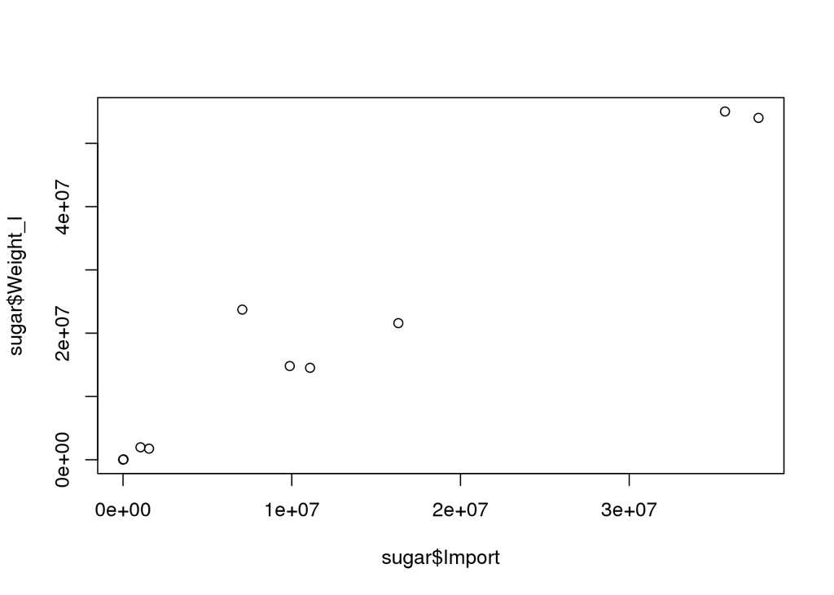

```r
plot(sugar$Import, sugar$Weight_I)
```

You can spot an increasing trend among the data points. This of course makes sense: the more sugar is traded, the higher the weight that’s traded.

#### Import SPSS data with haven

The `haven` package can also import data files from SPSS. Again, importing the data is pretty straighforward. Depending on the SPSS data file you’re working with, you’ll need either `read_sav()` for `.sav` files or `read_por()` for `.por` files.

```r
# haven is already loaded

# Import person.sav: traits
traits <- read_sav("person.sav")

# Summarize traits
summary(traits)

# Print out a subset
subset(traits,Extroversion > 40 & Agreeableness > 40)
```

#### Factorize, round two

In the last exercise you learned how to import a data file using the command `read_sav()`. With SPSS data files, it can also happen that some of the variables you import have the `labelled` class. This is done to keep all the labelling information that was originally present in the `.sav` and `.por` files. It’s advised to coerce (or change) these variables to factors or other standard R classes.

```r
# haven is already loaded

# Import SPSS data from the URL: work
work <- read_sav("employee.sav")

# Display summary of work$GENDER
summary(work$GENDER)


# Convert work$GENDER to a factor
work$GENDER <- as_factor(work$GENDER)


# Display summary of work$GENDER again
summary(work$GENDER)
```

#### Import STATA data with foreign

The `foreign` package offers a simple function to import and read *STATA* data: `read.dta()`.

```r
# Load the foreign package
library(foreign)

# Import florida.dta and name the resulting data frame florida
florida <- read.dta("florida.dta")

# Check tail() of florida
tail(florida)
```

Data can be very diverse, going from character vectors to categorical variables, dates and more. It’s in these case that the additional arguments of `read.dta()` will come in handy.

The arguments you will use most often are `convert.dates`, `convert.factors`, `missing.type` and `convert.underscore`. Their meaining is pretty straightforward. It’s all about correctly converting STATA data to standard R data structures.

```r
library(foreign)

# Specify the file path using file.path(): path
path <- file.path("worldbank", "edequality.dta")
url <- "http://s3.amazonaws.com/assets.datacamp.com/production/course_1478/datasets/edequality.dta"

# Create and print structure of edu_equal_1
edu_equal_1 <- read.dta(url)
str(edu_equal_1)
```

```
## 'data.frame':    12214 obs. of  27 variables:
##  $ hhid              : num  1 1 1 2 2 3 4 4 5 6 ...
##  $ hhweight          : num  627 627 627 627 627 ...
##  $ location          : Factor w/ 2 levels "urban location",..: 1 1 1 1 1 2 2 2 1 1 ...
##  $ region            : Factor w/ 9 levels "Sofia city","Bourgass",..: 8 8 8 9 9 4 4 4 8 8 ...
##  $ ethnicity_head    : Factor w/ 4 levels "Bulgaria","Turks",..: 2 2 2 1 1 1 1 1 1 1 ...
##  $ age               : num  37 11 8 73 70 75 79 80 82 83 ...
##  $ gender            : Factor w/ 2 levels "male","female": 2 2 1 1 2 1 1 2 2 2 ...
##  $ relation          : Factor w/ 9 levels "head                      ",..: 1 3 3 1 2 1 1 2 1 1 ...
##  $ literate          : Factor w/ 2 levels "no","yes": 1 2 2 2 2 2 2 2 2 2 ...
##  $ income_mnt        : num  13.3 13.3 13.3 142.5 142.5 ...
##  $ income            : num  160 160 160 1710 1710 ...
##  $ aggregate         : num  1042 1042 1042 3271 3271 ...
##  $ aggr_ind_annual   : num  347 347 347 1635 1635 ...
##  $ educ_completed    : int  2 4 4 4 3 3 3 3 4 4 ...
##  $ grade_complete    : num  4 3 0 3 4 4 4 4 5 5 ...
##  $ grade_all         : num  4 11 8 11 8 8 8 8 13 13 ...
##  $ unemployed        : int  2 1 1 1 1 1 1 1 1 1 ...
##  $ reason_OLF        : int  NA NA NA 3 3 3 9 9 3 3 ...
##  $ sector            : int  NA NA NA NA NA NA 1 1 NA NA ...
##  $ occupation        : int  NA NA NA NA NA NA 5 5 NA NA ...
##  $ earn_mont         : num  0 0 0 0 0 0 20 20 0 0 ...
##  $ earn_ann          : num  0 0 0 0 0 0 240 240 0 0 ...
##  $ hours_week        : num  NA NA NA NA NA NA 30 35 NA NA ...
##  $ hours_mnt         : num  NA NA NA NA NA ...
##  $ fulltime          : int  NA NA NA NA NA NA 1 1 NA NA ...
##  $ hhexp             : num  100 100 100 343 343 ...
##  $ legacy_pension_amt: num  NA NA NA NA NA NA NA NA NA NA ...
##  - attr(*, "datalabel")= chr ""
##  - attr(*, "time.stamp")= chr ""
##  - attr(*, "formats")= chr  "%9.0g" "%9.0g" "%9.0g" "%9.0g" ...
##  - attr(*, "types")= int  100 100 108 108 108 100 108 108 108 100 ...
##  - attr(*, "val.labels")= chr  "" "" "location" "region" ...
##  - attr(*, "var.labels")= chr  "hhid" "hhweight" "location" "region" ...
##  - attr(*, "expansion.fields")=List of 12
##   ..$ : chr  "_dta" "_svy_su1" "cluster"
##   ..$ : chr  "_dta" "_svy_strata1" "strata"
##   ..$ : chr  "_dta" "_svy_stages" "1"
##   ..$ : chr  "_dta" "_svy_version" "2"
##   ..$ : chr  "_dta" "__XijVarLabcons" "(sum) cons"
```

[output cut: 18 more lines]

```
##   .. ..- attr(*, "names")= chr  "head                      " "spouse/partner            " "child                     " "son/daughter-in-law       " ...
##   ..$ lit     : Named int  1 2
##   .. ..- attr(*, "names")= chr  "no" "yes"
##   ..$         : Named int  1 2 3 4
##   .. ..- attr(*, "names")= chr  "never attanded" "primary" "secondary" "postsecondary"
##   ..$         : Named int  1 2
##   .. ..- attr(*, "names")= chr  "Not unemployed" "Unemployed"
##   ..$         : Named int  1 2 3 4 5 6 7 8 9 10
##   .. ..- attr(*, "names")= chr  "student" "housewife/childcare" "in retirement" "illness, disability" ...
##   ..$         : Named int  1 2 3 4 5 6 7 8 9 10
##   .. ..- attr(*, "names")= chr  "agriculture" "mining" "manufacturing" "utilities" ...
##   ..$         : Named int  1 2 3 4 5
##   .. ..- attr(*, "names")= chr  "private company" "public works program" "government,public sector, army" "private individual" ...
##   ..$         : Named int  1 2
##   .. ..- attr(*, "names")= chr  "no" "yes"
```

For this data, the first version (where you simply specified the file path) will be most useful to work with.

#### Do you know your data?

The previous exercise dealt about socio-economic indicators and access to education of different individuals.

For example, you can ask yourself how many observations have an `age` higher than 40 adn are `literate`.

```r
nrow(subset(edu_equal_1, age > 40 & literate == "yes"))
```

```
## [1] 6506
```

How many observations from Bulgaria have an income above 1000 ?

```r
nrow(subset(edu_equal_1, ethnicity_head == "Bulgaria" & income > 1000))
```

```
## [1] 8997
```

The data frame contains 8997 individuals with a Bulgarian ethnicity whose income is above 1000.

#### Import SPSS data with foreign

All great things come in pairs. Where `foreign` provided `read.dta()` to read Stata data, there’s also `read.spss()` to read SPSS data files. To get a data frame, make sure to set `to.data.frame = TRUE` inside `read.spss()`.

```r
# foreign is already loaded

url <- "http://s3.amazonaws.com/assets.datacamp.com/production/course_1478/datasets/international.sav"

# Import international.sav as a data frame: demo
demo <- read.spss(url, to.data.frame = TRUE)
```

```
## re-encoding from CP1252
```

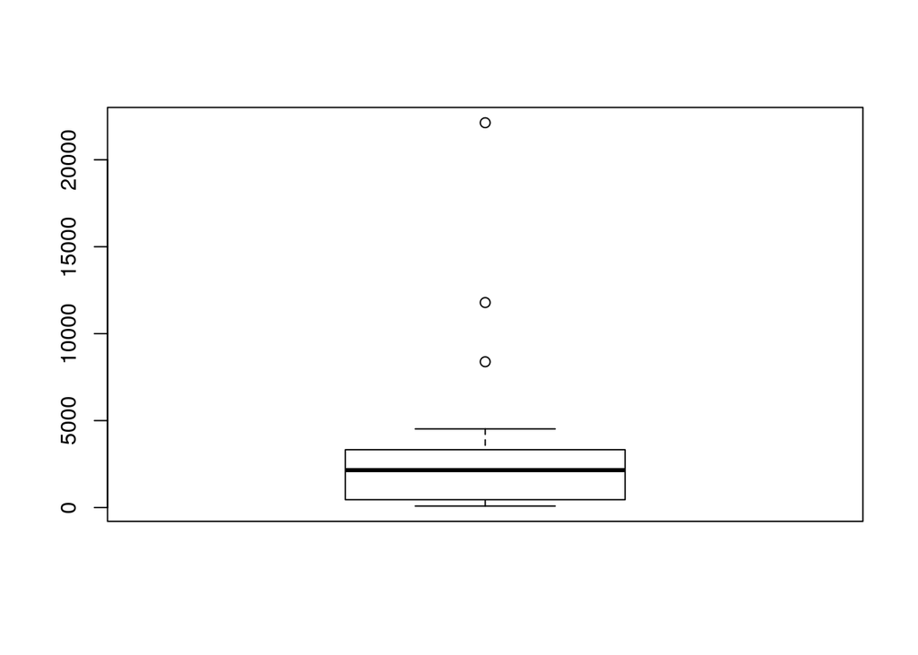

```r
# Create boxplot of gdp variable of demo
boxplot(demo$gdp)
```

#### Excursion: Correlation

If you’re familiar with statistic, you’ll have heard about Pearson’Correlation. It is a measurement to evaluate the linear dependency between two variables, say $X$ and $Y$. It can range from -1 to 1; if it’s close to 1 it means that there is a strong positive association between the variables. If $X$ is high, also $Y$ tends to be high. If it’s close to -1, there is a strong negative association: if $X$ is high, $Y$ tends to be low. When the Pearson correlation between two variables is 0, these variables are possibly independent: there is no association between $X$ and $Y$.

You can calculate the correlation between two vectors with the `cor()` function. Take this code for example, that computes the correlation between the columns `height` and `width` of a fictional data frame `size`:

```
cor(size$height, size$width)
```

What is the correlation coefficient for the two numerical variables `gdp` and `f_illit` (female illiteracy rate)?

```r
cor(demo$gdp, demo$f_illit)
```

```
## [1] -0.4476856
```

That indicates a negative association among GDP and female illiteracy.

#### Import SPSS data with foreign

In the previous exercise, you used the `to.data.frame` argument inside `read.spss()`. There are many other ways in which to customize the way your SPSS data is imported.

In this exercise you will experiment with another argument, `use.value.labels`. It specifies whether variables with value labels should be converted into R factors with levels that are named accordingly. The argument is `TRUE` by default which means that so called labelled variable inside SPSS are converted to factor inside R.

```r
# foreign is already loaded

# Import international.sav as demo_1
demo_1 <- read.spss(url, to.data.frame = TRUE)
```

```
## re-encoding from CP1252
```

```r
# Print out the head of demo_1
head(demo_1)
```

```
##   id              country  contint m_illit f_illit lifeexpt  gdp
## 1  1 Argentina            Americas     3.0     3.0       16 3375
## 2  2 Benin                  Africa    45.2    74.5        7  521
## 3  3 Burundi                Africa    33.2    48.1        5   86
## 4  4 Chile                Americas     4.2     4.4       14 4523
## 5  5 Dominican Republic   Americas    12.0    12.7       12 2408
## 6  6 El Salvador          Americas    17.6    22.9       11 2302
```

```r
# Import international.sav as demo_2
demo_2 <- read.spss(url, to.data.frame = TRUE,
use.value.labels = FALSE)
```

```
## re-encoding from CP1252
```

```r
# Print out the head of demo_2
head(demo_2)
```

```
##   id              country contint m_illit f_illit lifeexpt  gdp
## 1  1 Argentina                  2     3.0     3.0       16 3375
## 2  2 Benin                      1    45.2    74.5        7  521
## 3  3 Burundi                    1    33.2    48.1        5   86
## 4  4 Chile                      2     4.2     4.4       14 4523
## 5  5 Dominican Republic         2    12.0    12.7       12 2408
## 6  6 El Salvador                2    17.6    22.9       11 2302
```